# Analysis of environmental effects on Chinook salmon from the Willamette River basin

[**Mark D. Scheuerell**](https://faculty.washington.edu/scheuerl/)  
*Fish Ecology Division, Northwest Fisheries Science Center, National Marine Fisheries Service, National Oceanic and Atmospheric Administration, Seattle, WA USA, mark.scheuerell@noaa.gov*

**J. Tyrell Deweber**  
*Oregon Cooperative Fish & Wildlife Research Unit, Department of Fisheries & Wildlife, Oregon State University, Corvallis, OR USA, Jefferson.Deweber@oregonstate.edu*

**Tom Friesen**  
*Oregon Department of Fish and Wildlife, Corvallis, OR USA, tom.friesen@oregonstate.edu*

This is version 0.17.11.03.

# 1 Requirements

All analyses require the [R software](https://cran.r-project.org/) (v3.3+) for data retrieval, data processing, and summarizing model results, and the [JAGS software](http://mcmc-jags.sourceforge.net/) (v4.2.0) for Markov chain Monte Carlo (MCMC) simulation. Please note that some of the R code below may not work with older versions of JAGS due to some changes in the ways that arrays are handled.

We also need a few packages that are not included with the base installation of R, so we begin by installing them (if necessary) and then loading them.

```r
if(!require("EGRET")) {
  install.packages("EGRET")
  library("EGRET")
}
if(!require("R2jags")) {
  install.packages("R2jags")
  library("R2jags")
}
if(!require("RCurl")) {
  install.packages("RCurl")
  library("RCurl")
}
if(!require("gsl")) {
  install.packages("gsl")
  library("gsl")
}
if(!require("reshape2")) {
  install.packages("reshape2")
  library("reshape2")
}
if(!require("viridis")) {
  install.packages("viridis")
  library("viridis")
}
```

# 2 User inputs

1. observed total number of adult spawners (escapement) by year;
2. observed age composition of adult spawners by year;
3. observed total harvest by year;
4. metadata for the covariates.

The metadata for the covariates is a .csv file with the following columns:

1. `spp`: the species to which the covariate applies
2. `life_stage`: life stage at which the effect is thought to occur
3. `covariate`: type of covariate (e.g., flow, temperature)
4. `code`: USGS code for data type (i.e., usually 5-digit integer)
5. `long_name`: long name for the covariate
6. `short_name`: function name to derive the covariate
7. `lag_1`: years to lag begin date
8. `lag_2`: years to lag end date
9. `begin`: beginning date as 2-digit text (ie, mo-yr)
10. `end`: ending date as 2-digit text (ie, mo-yr)
11. `location`: description of location
12. `gage`: USGS gage number
13. `flag`: flag to include (1) or exclude (0) the covariate
14. `flow_scen`: flag to include (1) or exclude (0) flow scenario
15. `group`: integer indicator for life stage grouping

Let’s also define the following parameters, which will be referenced throughout the analysis.

- `n_yrs`: number of calendar years of data
- `A`: number of age classes
- `M`: number of covariates

```r
## 1. file with escapement data
## [n_yrs x 2] matrix of obs counts; 1st col is calendar yr
fn_esc <- "chin_esc.csv"

## 2. file with age comp data
## [n_yrs x (1+A)]; 1st col is calendar yr
fn_age <- "chin_agecomp.csv"
## min & max ages
age_min <- 3
age_max <- 6
## years, if any, of age-comp to skip; see below
age_skip <- 0

## 3. file with harvest data
## [n_yrs x 2] matrix of obs catch; 1st col is calendar yr
fn_harv <- "chin_harv.csv"

## 4. covariate metadata
cov_meta_file <- "chin_cov_metadata.csv"

## URL for example data files
## set to NULL if using a local folder/directory
ex_url <- "https://raw.githubusercontent.com/mdscheuerell/willamette/master/data/"
```

Next we specify some additional information regarding scenarios and forecasting, if desired.

```r
## number of years of forecasts
n_fore <- 1

## file where to save JAGS model
fn_jags <- "Willamette_Chin_SR_flow_models_mainstem_JAGS.txt"

## upper threshold for Gelman & Rubin's (1992) potential scale reduction factor (Rhat).
Rhat_thresh <- 1.1

## threshold values for CI's
CI_vec <- c(0.025,0.5,0.975)

## FLOW SCENARIOS
## dir with flow scenarios
scen_dir <- "WBR_ScenarioPreds_06Mar2017"
## scenario names
scen_names <- c("unregulated","BiOp","lowApril","Recess",
                "LowRecess","BiOpTrib","LowSummer","NMFS1",
                "Corps1","Corps2","OSU1")
## spawner abundances to consider
scen_sp <- c(5,10,15,20)*1000
## first year of scenarios
scen_yr_frst <- 1929
## last year of scenarios
scen_yr_last <- 2007
```

# 3 Function definitions

```r
## Re2prec
## converts any real number to round/floor/ceiling
Re2prec <- function(x,map="round",prec=1) {
  ## 'map' can be round, floor, or ceiling
  ## 'prec' is nearest value (eg, 0.1 means to nearest tenth); default 1 gives normal behavior
  if(prec<=0) { stop("\"prec\" cannot be less than or equal to 0") }
  do.call(map,list(x/prec))*prec
}

## over90k
## returns the total number of days that flow exceeded 90k cfs
over90k <- function(x) {
  return(sum(x >= 90000))
}

## min7mean
## returns the min of 7-day means over period
min7mean <- function(x) {
  return(round(min(filter(x, rep(1,7)/7, "convolution", sides=1), na.rm=TRUE),0))
}

## max7mean
## returns the max of 7-day means over period
max7mean <- function(x) {
  return(round(max(filter(x, rep(1,7)/7, "convolution", sides=1), na.rm=TRUE),0))
}

## med7mean
## returns the max of 7-day means over period
med7mean <- function(x) {
  return(round(median(filter(x, rep(1,7)/7, "convolution", sides=1), na.rm=TRUE),0))
}

## rng7mean
## returns the max of 7-day means over period
rng7mean <- function(x) {
  return(round(diff(range(filter(x, rep(1,7)/7, "convolution", sides=1), na.rm=TRUE)),0))
}

## range2
## returns the range as a scalar = max-min
range2 <- function(x) {
  return(diff(range(x)))
}

## DD15
## returns the cumulative number of degree days > 15C
DD15 <- function(x) {
  return(sum(filter(x, rep(1,7)/7, "convolution", sides=1) >= 15, na.rm=TRUE))
}

## colVars; from Gelman
## returns the column-wise variance of a matrix
colVars <- function(a) {
    n <- dim(a)[[1]]
    c <- dim(a)[[2]]
    mm <- matrix(.colMeans(a, n, c), n, c, byrow = TRUE)
    return(.colMeans(((a - mm) ^ 2), n, c) * n / (n - 1))
}

## waic; from Gelman
## computes WAIC based on pointwise log-like
waic <- function(log_lik) {
  S <- nrow(log_lik)
  n <- ncol(log_lik)
  lpd <- log(colMeans(exp(log_lik)))
  p_waic <- colVars(log_lik)
  elpd_waic <- lpd - p_waic
  waic <- -2*elpd_waic
  loo_weights_raw <- 1/exp(log_lik-max(log_lik))
  loo_weights_normalized <- loo_weights_raw /
    matrix(colMeans(loo_weights_raw),nrow=S,ncol=n,byrow=TRUE)
  loo_weights_regularized <- pmin(loo_weights_normalized, sqrt(S))
  elpd_loo <- log(colMeans(exp(log_lik)*loo_weights_regularized) /
                    colMeans(loo_weights_regularized))
  p_loo <- lpd - elpd_loo
  pointwise <- cbind(waic,lpd,p_waic,elpd_waic,p_loo,elpd_loo)
  total <- colSums(pointwise)
  se <- sqrt(n*colVars(pointwise))
  return(list(waic=total["waic"],
              elpd_waic=total["elpd_waic"],
              p_waic=total["p_waic"],
              elpd_loo=total["elpd_loo"],
              p_loo=total["p_loo"],
              pointwise=pointwise,
              total=total,
              se=se))
}
```

# 4 Loading the fish data

Here we load in the first three data files and do some simple calculations and manipulations.

First the spawner data:

```r
## escapement
dat_esc <- read.csv(text = getURL(paste0(ex_url,fn_esc)))
## use total counts
dat_esc <- dat_esc[dat_esc$group=="total",-1]
## inspect
dat_esc
```

```
##    year unmarked
## 35 1999     7689
## 36 2000     9703
## 37 2001    11904
## 38 2002    21538
## 39 2003    22767
## 40 2004    19056
## 41 2005     8665
## 42 2006     9810
## 43 2007     7903
## 44 2008     5463
## 45 2009     7706
## 46 2010    14148
## 47 2011    13427
## 48 2012     8715
## 49 2013     7352
## 50 2014     6696
## 51 2015     9429
```

```r
## years of data
dat_yrs <- dat_esc$year
## number of years of data
n_yrs <- length(dat_yrs)
## get first & last years
yr_frst <- min(dat_yrs)
yr_last <- max(dat_yrs)
## log of escapement
ln_dat_esc <- c(log(dat_esc[,-1]),rep(NA,n_fore))
```

Next the age composition data:

```r
## age comp data
dat_age <- read.csv(text = getURL(paste0(ex_url,fn_age)))
## use total age counts by year
dat_age <- dat_age[dat_age$site=="all" & dat_age$year>=yr_frst & dat_age$year<=yr_last,]
## drop first age_min+age_skip rows; drop site & year col
dat_age <- dat_age[-(1:(age_min+age_skip)),-c(1,2)]
## num of age classes
A <- age_max-age_min+1
## add row(s) of NA's for forecast years
dat_age <- rbind(dat_age,matrix(0,n_fore,A,dimnames=list(n_yrs+seq(n_fore),colnames(dat_age))))
## total num of age obs by cal yr
dat_age[,"sum"] <- apply(dat_age,1,sum)
## row indices for any years with no obs age comp
idx_NA_yrs <- which(dat_age$sum<A,TRUE)
## replace 0's in yrs w/o any obs with NA's
dat_age[idx_NA_yrs,(1:A)] <- NA
## change total in yrs w/o any obs from 0 to A to help dmulti()
dat_age[idx_NA_yrs,"sum"] <- A
## convert class
dat_age <- as.matrix(dat_age)
## inspect
dat_age
```

```
##     age_3 age_4 age_5 age_6  sum
## 127     8   397   359     5  769
## 128     2   158   288    13  461
## 129     1   208   377     6  592
## 130     8    82   241    11  342
## 131     7   173   142     4  326
## 132    29   251   567    22  869
## 133   105   488   280    13  886
## 134    12   467   199    18  696
## 135    30   200   219     5  454
## 136    17   814   303    11 1145
## 137     5    90   288    22  405
## 138    57   413   239    12  721
## 139    96   940   447    11 1494
## 140    66   713   176     7  962
## 18     NA    NA    NA    NA    4
```

And then the harvest data:

```r
## harvest
dat_harv <- read.csv(text = getURL(paste0(ex_url,fn_harv)))
## trim to correct years & drop year col
dat_harv <- c(dat_harv[dat_harv$year>=yr_frst & dat_harv$year<=yr_last,-1],rep(0,n_fore))
```

# 5 Loading the covariates

The analyses are based upon several environmental indicators related to river discharge and temperature. Load the data file containing all of the metadata regarding the specific covariates to be used.

```r
cov_meta <- read.csv(text = getURL(paste0(ex_url,cov_meta_file)), stringsAsFactors = FALSE)
cov_meta$code <- gsub("\"","",cov_meta$code)
cov_meta$begin <- gsub("\"","",cov_meta$begin)
cov_meta$end <- gsub("\"","",cov_meta$end)
```

We need to define the beginning and ending dates for the covariates

```r
yr1 <- yr_frst
yr2 <- yr_last - age_min + n_fore
## start date
startDate <- paste0(yr1 + min(cov_meta$lag_1),"-01-01")
## end date
endDate <- paste0(yr2 + max(cov_meta$lag_2),"-12-31")
```

## 5.1 River discharge

We begin by getting the daily flow data from the US Geological Service [National Water Information System](http://waterdata.usgs.gov/nwis) for the complete time period of interest.

```r
## metadata for flow covariates
flow_meta <- subset(cov_meta, covariate=="flow" & flag==1)
## data to get: flow (cfs)
parameterCD <- "00060"
## get all flow data for period of interest & gages
gages <- unique(flow_meta$gage)
n_gages <- length(gages)
tmp <- readNWISDaily(gages[1], parameterCD, startDate, endDate, convert=FALSE)
tmp$yr <- floor(tmp$DecYear)
flow_data <- tmp[,c("Date","waterYear","yr","Month","Day")]
colnames(flow_data) <- c("date","H2Oyr","yr","mon","day")
flow_data[,as.character(gages[1])] <- tmp$Q
if(n_gages > 1) {
  for(i in 2:n_gages) {
    tmp <- readNWISDaily(gages[i], parameterCD, startDate, endDate, convert=FALSE)
    flow_data[,as.character(gages[i])] <- tmp$Q
  }
}
```

```
## There are 6574 data points, and 6574 days.
```

Now we can extract the specific flow covariates that relate to each of the hypotheses about the affected life stage.

```r
cov_flow <- matrix(NA,length(seq(yr1,yr2)),dim(flow_meta)[1]+1)
n_mods <- dim(cov_flow)[2] - 1
cov_flow[,1] <- seq(yr_frst,yr2)
for(i in 1:dim(flow_meta)[1]) {
  fn <- get(flow_meta[i,"short_name"])
  cnt <- 1
  for(t in yr1:yr2) {
    beg <- paste0(t+flow_meta[i,"lag_1"],"-",flow_meta[i,"begin"])
    end <- paste0(t+flow_meta[i,"lag_2"],"-",flow_meta[i,"end"])
    tmp <- flow_data[flow_data$date>=beg & flow_data$date<=end, as.character(flow_meta[i,"gage"])]
    cov_flow[cnt,i+1] <- fn(tmp)
    cnt <- cnt+1
  }
}
print(round(cov_flow,0))
```

```
##       [,1]   [,2]  [,3]  [,4]  [,5]  [,6]  [,7]  [,8]  [,9] [,10] [,11]
##  [1,] 1999 117100 53657 15014 21214 36129 21114 19443 22157 36129  7354
##  [2,] 2000  81000 36371  9681 19586 30286 20604 18900 17000 30286  6854
##  [3,] 2001  26700 11729  6667 14871 20143 13476 14114 14643 18371  5176
##  [4,] 2002  81943 35143  8467 15629 54300 45833 17671 15429 16271  6469
##  [5,] 2003  74100 29157  7089 16229 39429 32340 34014 14843 21471  6016
##  [6,] 2004  75943 31243  8930 15257 19686 10756 15343 14414 18600  6803
##  [7,] 2005  54343 12829  9597 17029 27286 17689 16443 15414 27286  7043
##  [8,] 2006 125286 26571  9583 17243 25929 16346 18571 15929 19071  6497
##  [9,] 2007  83557 40271  7937 15143 19529 11591 18043 14286 15757  5854
## [10,] 2008  73243 34250 16071 24186 43214 27143 17114 24400 43214  6570
## [11,] 2009  95286 22457  8699 19714 39557 30859 18543 17271 39557  6310
## [12,] 2010  61129 21100 13514 24486 71157 57643 20214 18029 29214  6581
## [13,] 2011  84286 37814 16371 28657 49514 33143 31314 22257 29986  7639
## [14,] 2012 122871 29071 15186 26614 93357 78171 33457 19229 41200  7877
```

[output cut: 33 more lines]

```r
write.csv(cov_flow, row.names = FALSE,
          file="Willamette_Chin_SR_flow_models_mainstem_covariates.csv")
```

Here are plots of the pairwise correlation coefficients for each of the flow covariates.

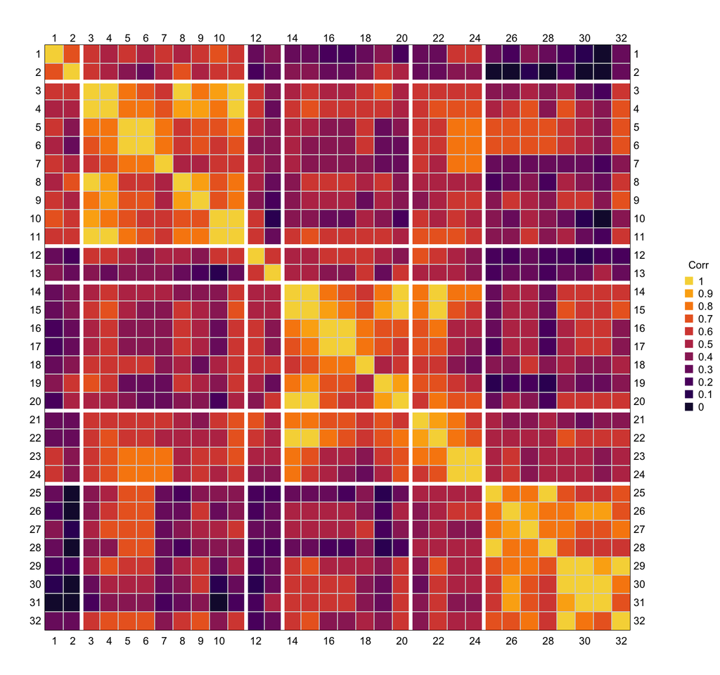

```r
## min cor to consider
thrsh <- 0.7
## color palette
clr <- viridis(n=11, begin=0.1, end=0.9, option="B")
## transformed matrix of corr coefs
tcc <- t(apply(cor(cov_flow[,-1]),1,rev))
nn <- dim(tcc)[1]
par(mai=rep(0.5,4), omi=c(0,0,0,0.5))
## color image
image(tcc, xaxt="n", yaxt="n", col=clr)
axis(1,at=(seq(0,nn,length.out=nn)+1/nn)/nn, labels=seq(nn), cex.axis=0.7, tick=FALSE, line=-1)
axis(2,at=rev(seq(0,nn,length.out=nn)+1/nn)/nn, labels=seq(nn), las=1, cex.axis=0.7, tick=FALSE, line=-0.8)
axis(3,at=(seq(0,nn,length.out=nn)+1/nn)/nn, labels=seq(nn), cex.axis=0.7, tick=FALSE, line=-1)
axis(4,at=rev(seq(0,nn,length.out=nn)+1/nn)/nn, labels=seq(nn), las=1, cex.axis=0.7, tick=FALSE, line=-0.8)
grid(nx=n_mods,ny=n_mods, lty="solid")
## show major breaks by life stage
bls <- cumsum(table(cov_meta$group))[-length(unique(cov_meta$group))] + 1
abline(h=seq(par()$usr[1],par()$usr[2],length.out=nn+1)[nn-bls+2], lwd=4, col="white")
abline(v=seq(par()$usr[1],par()$usr[2],length.out=nn+1)[bls], lwd=4, col="white")
## add legend
legend(x="right", legend=rev(seq(0,10)/10), title="Corr",
       inset=c(-0.15,0), xpd=NA,
       col=rev(viridis(n=11, begin=0.1, end=0.9, option="B")), bg="white",
       pch=15, pt.cex=1.2, cex=0.7, bty="n")
```

## 5.2 Water temperature

Next we get the daily temperature data from the US Geological Service [National Water Information System](http://waterdata.usgs.gov/nwis) for the complete time period of interest.

```r
## metadata for flow covariates
temp_meta <- subset(cov_meta, covariate=="temp" & flag==1)
## data to get: temp (C)
parameterCD <- "00010"
## get all flow data for period of interest & gages
gages <- unique(temp_meta$gage)
n_gages <- length(gages)
tmp <- readNWISDaily(gages[1], parameterCD, startDate, endDate, convert=FALSE)
tmp$yr <- floor(tmp$DecYear)
temp_data <- tmp[,c("Date","waterYear","yr","Month","Day")]
colnames(temp_data) <- c("date","H2Oyr","yr","mon","day")
temp_data[,as.character(gages[1])] <- tmp$Q
if(n_gages > 1) {
  for(i in 2:n_gages) {
    tmp <- readNWISDaily(gages[i], parameterCD, startDate, endDate, convert=FALSE)
    flow_data[,as.character(gages[i])] <- tmp$Q
  }
}
```

Now we can extract the specific temperature covariates that relate to each of the hypotheses about the affected life stage.

```r
cov_temp <- matrix(NA,length(seq(yr1,yr2)),dim(temp_meta)[1]+1)
cov_temp[,1] <- seq(yr_frst,yr2)
for(i in 1:dim(temp_meta)[1]) {
  fn <- get(temp_meta[i,"short_name"])
  cnt <- 1
  for(t in yr1:yr2) {
    beg <- paste0(t+temp_meta[i,"lag_1"],"-",temp_meta[i,"begin"])
    end <- paste0(t+temp_meta[i,"lag_2"],"-",temp_meta[i,"end"])
    tmp <- temp_data[temp_data$date>=beg & temp_data$date<=end, as.character(temp_meta[i,"gage"])]
    if(length(tmp)>0) {
      cov_temp[cnt,i+1] <- fn(tmp)
    } else {
      cov_temp[cnt,i+1] <- NA
    }
    cnt <- cnt+1
  }
}
cov_temp
```

# 6 Specifying model in JAGS

Now we can specify the model in JAGS. Note that the code below is not written to be universally generic with respect to the number of covariates, but rather to emphasize how to incorporate the three we used in this specific application. The important thing is the number of covariate parameters in the `PRIORS` and `LIKELIHOOD` sections (i.e., there must be a unique `c_Name` parameter for each of the *MM* covariates).

```r
cat("

model {

    ##--------
    ## PRIORS
    ##--------
    ## alpha = exp(a) = intrinsic productivity
    mu_Rkr_a ~ dnorm(0,1e-3)I(-4,4);
    alpha <- exp(mu_Rkr_a);
    E_Rkr_a <- mu_Rkr_a + var_Qr/(2 - 2*phi^2);

    ## covariate effects
    c1 ~ dnorm(0,0.001)

    ## strength of dens depend
    Rkr_b ~ dunif(0,0.01);

    ## AR(1) coef for proc errors
    phi ~ dunif(-0.999,0.999);

    ## process variance for recruits model
    sd_Qr ~ dunif(0.001,20);
    tau_Qr <- pow(sd_Qr,-2);
    var_Qr <- pow(sd_Qr,2)

    ## innovation in first year
    innov_1 ~ dnorm(0,tau_Qr*(1-phi*phi));

    ## obs variance for spawners
    sd_Rs ~ dunif(0.001,3);
    tau_Rs <- pow(sd_Rs,-2);
    var_Rs <- pow(sd_Rs,2)

    ## unprojectable early recruits;
    ## hyper mean across all popns
    Rec_mu ~ dnorm(0,0.001);
    ## hyper SD across all popns
    Rec_sig ~ dunif(0,100);
    ## precision across all popns
    Rec_tau <- pow(Rec_sig,-2);
    ## multipliers for unobservable total runs
    ttl_run_mu ~ dunif(1,5);
    ttl_run_tau ~ dunif(1,20);

    ## maturity schedule
    ## unif vec for Dirch prior
    for(i in 1:A) { theta[i] <- 1 }
    ## hyper-mean for maturity
    p_mu ~ ddirch(theta);
    ## hyper-prec for maturity
    p_pi ~ dunif(0.001,1e3);
    for(t in 1:(n_yrs-age_min+n_fore)) { p_vec[t,1:A] ~ ddirch(p_mu*p_pi) }

    ##------------
    ## LIKELIHOOD
    ##------------
    ## 1st brood yr requires different innovation
    ## predicted recruits in BY t
    ln_Rkr_a[1] <- mu_Rkr_a + c1*covar[1];
    E_ln_Rec[1] <- ln_Sp[1] + ln_Rkr_a[1] - Rkr_b*Sp[1] + phi*innov_1;
    tot_ln_Rec[1] ~ dnorm(E_ln_Rec[1],tau_Qr);
    res_ln_Rec[1] <- tot_ln_Rec[1] - E_ln_Rec[1];
    ## median of total recruits
    tot_Rec[1] <- exp(tot_ln_Rec[1]);

    ## R/S
    ln_RS[1] <- tot_ln_Rec[1] - ln_Sp[1];

    ## brood-yr recruits by age
    for(a in 1:A) {
        Rec[1,a] <- max(1,tot_Rec[1] * p_vec[1,a]);
        }

    ## brood years 2:(n_yrs-age_min)
    for(t in 2:(n_yrs-age_min+n_fore)) {
        ## predicted recruits in BY t
        ln_Rkr_a[t] <- mu_Rkr_a + c1*covar[t];
        E_ln_Rec[t] <- ln_Sp[t] + ln_Rkr_a[t] - Rkr_b*Sp[t] + phi*res_ln_Rec[t-1];
        tot_ln_Rec[t] ~ dnorm(E_ln_Rec[t],tau_Qr);
        res_ln_Rec[t] <- tot_ln_Rec[t] - E_ln_Rec[t];
        ## median of total recruits
        tot_Rec[t] <- exp(tot_ln_Rec[t]);
        ## R/S
        ln_RS[t] <- tot_ln_Rec[t] - ln_Sp[t];
        ## brood-yr recruits by age
        for(a in 1:A) {
            Rec[t,a] <- max(1,tot_Rec[t] * p_vec[t,a]);
            }
        } ## end t loop over year

    ## get total cal yr returns for first age_min yrs
    for(i in 1:(age_min+age_skip)) {
        ln_tot_Run[i] ~ dnorm(ttl_run_mu*Rec_mu,Rec_tau/ttl_run_tau);
        tot_Run[i] <- exp(ln_tot_Run[i]);
    }

    ## get predicted calendar year returns by age
    ## matrix Run has dim [(n_yrs-age_min) x A]
    ## step 1: incomplete early broods
    ## first cal yr of this grp is first brood yr + age_min + age_skip
    for(i in 1:(age_max-age_min-age_skip)) {
        ## projected recruits
        for(a in 1:(i+age_skip)) {
            Run[i,a] <- Rec[(age_skip+i)-a+1,a];
            }
        ## imputed recruits
        for(a in (i+1+age_skip):A) {
            lnRec[i,a] ~ dnorm(Rec_mu,Rec_tau);
            Run[i,a] <- exp(lnRec[i,a]);
            }
        ## total run size
        tot_Run[i+age_min+age_skip] <- sum(Run[i,1:A]);
        ## predicted age-prop vec for multinom
        for(a in 1:A) {
            age_v[i,a] <- Run[i,a] / tot_Run[i+age_min];
            }
        ## multinomial for age comp
        dat_age[i,1:A] ~ dmulti(age_v[i,1:A],dat_age[i,A+1]);
    lp_age[i] <- logdensity.multi(dat_age[i,1:A],age_v[i,1:A],dat_age[i,A+1]);
        }

    ## step 2: info from complete broods
    ## first cal yr of this grp is first brood yr + age_max
    for(i in (A-age_skip):(n_yrs-age_min-age_skip+n_fore)) {
        for(a in 1:A) {
            Run[i,a] <- Rec[(age_skip+i)-a+1,a];
            }
        ## total run size
        tot_Run[i+age_min+age_skip] <- sum(Run[i,1:A]);
        ## predicted age-prop vec for multinom
        for(a in 1:A) {
            age_v[i,a] <- Run[i,a] / tot_Run[i+age_min];
            }
        ## multinomial for age comp
        dat_age[i,1:A] ~ dmulti(age_v[i,1:A],dat_age[i,A+1]);
    lp_age[i] <- logdensity.multi(dat_age[i,1:A],age_v[i,1:A],dat_age[i,A+1]);
        }

    ## get predicted calendar year spawners
    ## first cal yr is first brood yr
    for(t in 1:(n_yrs+n_fore)) {
        ## obs model for spawners
    Sp[t] <- max(1,tot_Run[t] - dat_harv[t]);
        ln_Sp[t] <- log(Sp[t]);
        ln_dat_esc[t] ~ dnorm(ln_Sp[t], tau_Rs);
    lp_esc[t] <- logdensity.norm(ln_dat_esc[t],ln_Sp[t], tau_Rs)
        }

} ## end model description

", file=fn_jags)
```

# 7 Fitting the model

The last thing we need to do before fitting the model in JAGS is to specify:

1. the data and indices that go into the model;
2. the model parameters and states that we want JAGS to return;
3. the MCMC control parameters.

Please note that the following code takes ~3 min to run on a quad-core machine with 3.5 GHz Intel processors.

```r
## 1. data to pass to JAGS
dat_jags <- c("dat_age","ln_dat_esc","dat_harv","covar",
              "n_yrs","A","age_min","age_max","age_skip","n_fore")

## 2. model params/states for JAGS to return
par_jags <- c("alpha","E_Rkr_a","mu_Rkr_a","Rkr_b","ln_Rkr_a",
              "c1","lp_age","lp_esc",
              "Sp","Rec","tot_ln_Rec","ln_RS","p_vec",
              "var_Qr","var_Rs","res_ln_Rec")

## 3. MCMC control params
## MCMC parameters
mcmc_chains <- 4
mcmc_length <- 7e5
mcmc_burn <- 2e5
mcmc_thin <- 400
## total number of MCMC samples
mcmc_samp <- (mcmc_length-mcmc_burn)*mcmc_chains/mcmc_thin

## function to create JAGS inits
init_vals <- function() {
    list(mu_Rkr_a=1, c1=rnorm(1,0,0.1),
         Rkr_b=1/exp(mean(ln_dat_esc, na.rm=TRUE)),
         p_pi=1, p_mu=rep(1,A),
         p_vec=matrix(c(0.04,0.50,0.45,0.01),n_yrs-age_min+n_fore,A,byrow=TRUE),
         Rec_mu=log(1000),
         Rec_sig=0.1,
         tot_ln_Rec=rep(log(1000),n_yrs-age_min+n_fore),
         sd_Rs=0.1,
         innov_1=0,
         phi=0.5)
    }

## fit the model in JAGS & store results
mod_fits <- vector("list", n_mods)
for(i in 1:n_mods) {
  covar <- (cov_flow[,i+1]-mean(cov_flow[,i+1]))/sd(cov_flow[,i+1])
  dat_jags <- c("dat_age","ln_dat_esc","dat_harv","covar",
                "n_yrs","A","age_min","age_max","age_skip","n_fore")
  ## list of model info for JAGS
  mod_jags <- list(data=dat_jags,
                   inits=init_vals,
                   parameters.to.save=par_jags,
                   model.file=fn_jags,
                   n.chains=as.integer(mcmc_chains),
                   n.iter=as.integer(mcmc_length),
                   n.burnin=as.integer(mcmc_burn),
                   n.thin=as.integer(mcmc_thin),
                   DIC=TRUE)
  mod_fits[[i]] <- do.call(jags.parallel, mod_jags)
}
save(list=ls(), file="Willamette_Chin_SR_flow_models_mainstem.RData")
```

# 8 Finding the best model

Let’s examine Watanabe’s Akaike Information Criterion (WAIC) for each of the models to see which of the covariate scenarios seems to be best supported by the available data.

```r
WAIC <- vector("numeric",n_mods)
cc_smry_1 <- matrix(NA,n_mods,3)
colnames(cc_smry_1) <- paste0("linr_",c("lo","med","up"))
## extract log densities from JAGS objects
for(i in 1:n_mods) {
  ldens <- cbind(matrix(0,mcmc_samp,(age_min+age_skip)),
                 mod_fits[[i]]$BUGSoutput$sims.list$lp_age)
  ldens <- ldens + mod_fits[[i]]$BUGSoutput$sims.list$lp_esc
  WAIC[i] <- waic(ldens)$waic
  cc_smry_1[i,] <- mod_fits[[i]]$BUGSoutput$summary["c1", c("2.5%","50%","97.5%")]
}
d_WAIC <- round(WAIC-min(WAIC),1)
wt_WAIC <- exp(-0.5*d_WAIC)/sum(exp(-0.5*d_WAIC))
tbl_WAIC <- data.frame(life_stage=flow_meta$life_stage,
                       variable=sub(" of 7-day mean","",flow_meta$long_name),
                       begin=flow_meta$begin,
                       end=flow_meta$end,
                       lag=flow_meta$lag_1,
                       WAIC=round(WAIC,1),
                       d_WAIC=d_WAIC,
                       wt_WAIC=round(wt_WAIC,3),
                       round(cc_smry_1,2))
write.csv(tbl_WAIC,  row.names = FALSE,
          file = "Willamette_Chin_SR_flow_models_mainstem_model_selection_R_linear.csv")
best_idx <- which(tbl_WAIC$d_WAIC==0)
tbl_WAIC[,!(names(tbl_WAIC) %in% c("lag","WAIC"))]
```

```
##        life_stage variable begin   end d_WAIC wt_WAIC linr_lo linr_med
## 1        prespawn      Max 11-01 03-31    4.1   0.024   -0.14     0.21
## 2        prespawn   Median 11-01 03-31    4.9   0.016   -0.04     0.28
## 3        prespawn      Min 04-01 06-30    9.1   0.002   -0.38     0.08
## 4        prespawn   Median 04-01 06-30    9.6   0.002   -0.46     0.04
## 5        prespawn      Max 04-01 06-30    7.4   0.005   -0.34     0.06
## 6        prespawn    Range 04-01 06-30    7.6   0.004   -0.33     0.05
## 7        prespawn      Min 04-01 04-30   18.7   0.000   -0.14     0.35
## 8        prespawn      Min 05-01 05-31    4.2   0.023   -0.45    -0.04
## 9        prespawn      Max 05-01 05-31    0.6   0.140   -0.53    -0.13
## 10       prespawn      Min 07-01 09-30    8.9   0.002   -0.06     0.28
## 11       prespawn   Median 07-01 09-30   10.9   0.001   -0.21     0.20
## 12     incubation      Max 11-01 03-31    6.8   0.006   -0.32     0.05
## 13     incubation   Median 11-01 03-31    5.2   0.014   -0.29     0.07
## 14 1+ outmigrants      Min 04-01 06-30   10.2   0.001   -0.24     0.15
```

[output cut: 51 more lines]

The model with the most support from the data is number 28, which estimates a flow effect during the 2+ outmigrants stage as the “Range” beginning on 02-01 and ending on 04-30.

## 8.1 Model-averaged effects

Rather than focus on a best model, we can evaluate model-averaged predicted productivity across the various life stages.

```r
mm <- rep(tbl_WAIC$wt_WAIC[fs_idx], each=length(scen_sp)*n_yrs_scen)
tbl_fut_wtd <- mm * tbl_futures[,-c(1:3)]
wtd_avg <- 0
for(i in 1:nn) {
  wtd_avg <- wtd_avg + tbl_fut_wtd[(1:(length(scen_sp)*n_yrs_scen))+(i-1)*(length(scen_sp)*n_yrs_scen),]
}
wtd_avg <- cbind(year=rep(yrs_scen,each=length(scen_sp)),
                 spawners=rep(scen_sp,times=n_yrs_scen),
                 round(wtd_avg,2))
write.csv(wtd_avg, row.names = FALSE,
          file="Willamette_Chin_SR_flow_models_mainstem_model_avg_scenarios.csv")
```

## 8.2 Diagnostics

Here is a histogram of the Gelman & Rubin statistics $(R_{hat})$ for the estimated parameters from the best model. Recall that we set an upper threshold of 1.1, so any parameters with $(R_{hat})$ values larger than 1.1 deserve some additional inspection.

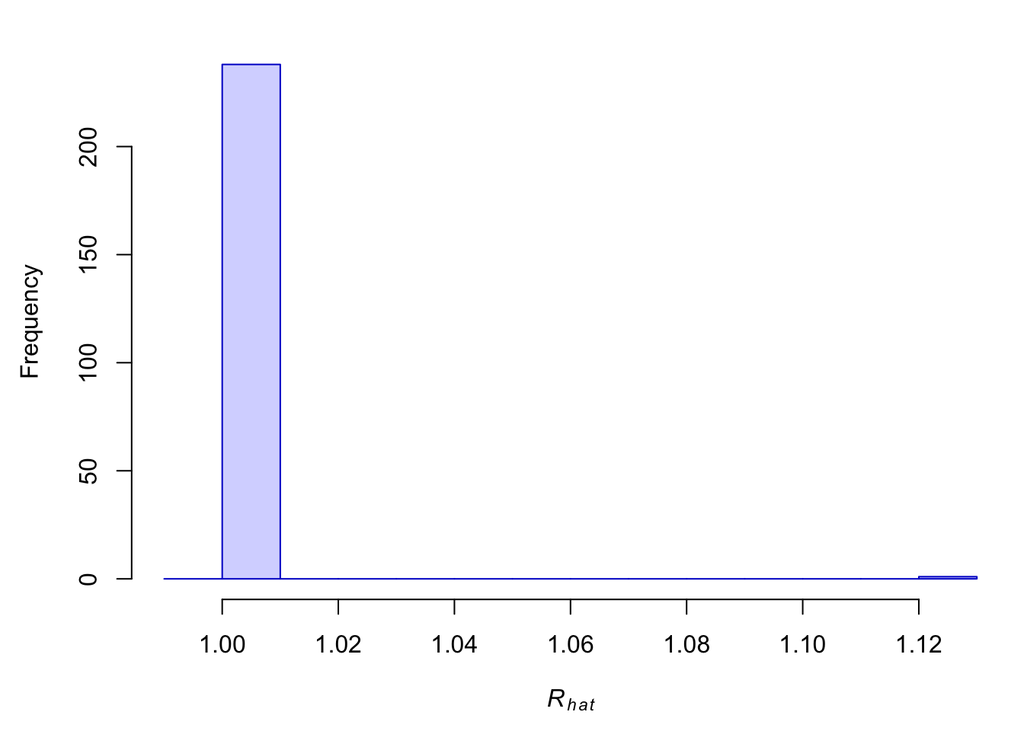

```r
mod_fit <- mod_fits[[best_idx]]
## Rhat values for all parameters
rh <- mod_fit$BUGSoutput$summary[,"Rhat"]
## histogram of Rhat values for all parameters
par(mai=c(0.9,0.9,0.3,0.1))
hist(rh, breaks=seq(0.99,ceiling(max(rh)/0.01)*0.01,by=0.01),main="",
     col=rgb(0,0,255,alpha=50,maxColorValue=255),border="blue3",xlab=expression(italic(R[hat])))
```

```r
## Rhat values > threshold
bad_Rhat <- rh[rh>Rhat_thresh]
## prop of params with Rhat > threshold
round(length(bad_Rhat)/length(rh),3)
```

```
## [1] 0.004
```

```r
## param names
par_names <- sub("\\[.*","",names(bad_Rhat))
## number of Rhat > threshold by param name
table(par_names)
```

```
## par_names
## E_Rkr_a
##       1
```

```r
## index values for offenders
idx <- as.integer(sub("(^.*\\[)([0-9]{1,3})(.*)","\\2",names(bad_Rhat)))
## data frame of offenders
(df <- data.frame(par=par_names, index=idx))
```

```
##       par index
## 1 E_Rkr_a    NA
```

# 9 Main results

Here is a table of summary statistics for some of the model parameters.

```r
tbl_smry <- mod_fit$BUGSoutput$summary[c("E_Rkr_a","Rkr_b","c1",
                                         "var_Qr","var_Rs"),
                                       c("mean","sd","2.5%","50%","97.5%")]
print(tbl_smry,digits=3,quote=FALSE,justify="right")
```

```
##              mean       sd      2.5%       50%    97.5%
## E_Rkr_a  1.22e+00 8.69e-01  4.76e-01  1.13e+00 2.312933
## Rkr_b    9.61e-05 2.93e-05  4.13e-05  9.39e-05 0.000162
## c1      -2.23e-01 1.64e-01 -5.36e-01 -2.28e-01 0.123593
## var_Qr   2.76e-01 2.02e-01  7.04e-02  2.22e-01 0.790839
## var_Rs   5.09e-02 5.65e-02  2.78e-04  3.52e-02 0.198632
```

## 9.1 Spawner-recruit relationship

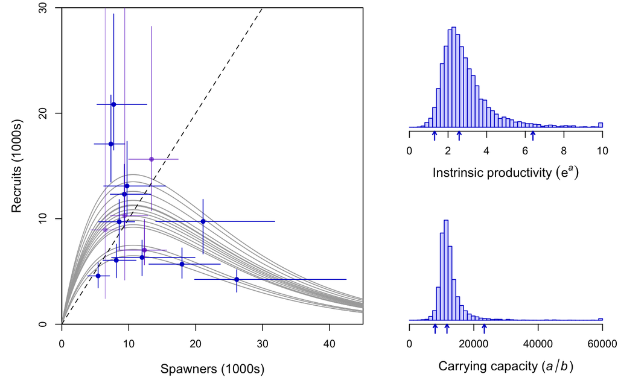

```r
layout(matrix(c(1,1,2,3),2,2),c(3,2),c(1,1))
offSet <- 0.06

## posterior of spawners
sDat <- apply(mod_fit$BUGSoutput$sims.list$Sp,2,quantile,CI_vec)
sDat <- sDat[,1:(n_yrs-age_min+n_fore)]
## posterior of recruits
rDat <- exp(apply(mod_fit$BUGSoutput$sims.list$tot_ln_Rec,2,quantile,CI_vec))
## median values for a & b
aa <- apply(mod_fit$BUGSoutput$sims.list$ln_Rkr_a,2,median)
bb <- apply(mod_fit$BUGSoutput$sims.list$Rkr_b,2,median)

## empty plot space for spawner-recruit relationships
dd <- 5000
yM <- Re2prec(max(rDat[2,]),"ceiling",dd*2)
xM <- Re2prec(max(sDat),"ceiling",dd)
par(mai=c(0.8,0.8,0.1,0.1), omi=c(0,0,0,0))
plot(sDat[2,],rDat[2,], xlim=c(0,xM), ylim=c(0,yM), pch=16, col="blue3", type="n",
     xaxs="i", yaxs="i", ylab="Recruits (1000s)", xlab="Spawners (1000s)", cex.lab=1.2,
     xaxt="n", yaxt="n")
axis(1, at=seq(0,xM,dd*2), labels=seq(0,xM,dd*2)/1000)
axis(2, at=seq(0,yM,dd*2), labels=seq(0,yM,dd*2)/1000)
for(i in 1:length(aa)) { lines(seq(xM)*exp(aa[i]-bb*seq(xM)), col="darkgray") }
## add S-R estimates and medians
abline(a=0,b=1,lty="dashed")
nCB <- n_yrs-age_max
points(sDat[2,1:nCB],rDat[2,1:nCB], xlim=c(0,xM), ylim=c(0,yM), pch=16, col="blue3")
segments(sDat[2,1:nCB],rDat[1,1:nCB],sDat[2,1:nCB],rDat[3,1:nCB], col="blue3")
segments(sDat[1,1:nCB],rDat[2,1:nCB],sDat[3,1:nCB],rDat[2,1:nCB], col="blue3")
nTB <- dim(sDat)[2]
clr <- rgb(100, 0, 200, alpha=seq(200,100,length.out=age_max-age_min+n_fore), maxColorValue=255)
segments(sDat[2,(nCB+1):nTB],rDat[1,(nCB+1):nTB],sDat[2,(nCB+1):nTB],rDat[3,(nCB+1):nTB], col=clr)
segments(sDat[1,(nCB+1):nTB],rDat[2,(nCB+1):nTB],sDat[3,(nCB+1):nTB],rDat[2,(nCB+1):nTB], col=clr)
points(sDat[2,(nCB+1):nTB],rDat[2,(nCB+1):nTB],
       xlim=c(0,xM), ylim=c(0,yM), pch=16, col=clr)

## posterior for exp(a)
clr <- rgb(0, 0, 255, alpha = 50, maxColorValue = 255)
par(mai=c(0.8,0.4,0.3,0.1))
## Ricker a
R_alpha_est <- mod_fit$BUGSoutput$sims.list$alpha
alphaCI <- quantile(R_alpha_est,c(0.025,0.5,0.975))
R_alpha_est[R_alpha_est>10] <- 10
hist(R_alpha_est,freq=FALSE,xlab="",main="",breaks=seq(0,10,0.2),
     col=clr, border="blue3", ylab="", cex.lab=1.2, yaxt="n")
aHt <- (par()$usr[4]-par()$usr[3])/12
arrows(alphaCI,par()$usr[3],alphaCI,par()$usr[3]-aHt,
       code=1,length=0.05,xpd=NA,col="blue3",lwd=1.5)
mtext(expression(paste("Instrinsic productivity ",(e^italic(a)))), 1, line=3, cex=1)

## posterior for a/b
par(mai=c(0.8,0.4,0.3,0.1))
aa <- matrix(mod_fit$BUGSoutput$sims.array[,,"E_Rkr_a"],ncol=1)
bb <- matrix(mod_fit$BUGSoutput$sims.array[,,"Rkr_b"],ncol=1)
R_b_est <- aa/bb
R_b_est <- R_b_est[R_b_est > 0]
R_b_CI <- quantile(R_b_est,c(0.025,0.5,0.975))
R_b_est[R_b_est>6e4] <- 6e4
brks <- seq(Re2prec(min(R_b_est),"floor",2000),6e4,length.out=length(seq(0,10,0.2)))
hist(R_b_est, freq=FALSE, breaks=brks, col=clr, border="blue3",
     xlab="", xaxt="n", yaxt="n",
     main="", ylab="", cex.lab=1.2)
axis(1, at=seq(Re2prec(min(R_b_est),"floor",2000),6e4,20000))
aHt <- (par()$usr[4]-par()$usr[3])/12
arrows(R_b_CI,par()$usr[3],R_b_CI,par()$usr[3]-aHt,
       code=1,length=0.05,xpd=NA,col="blue3",lwd=1.5)
mtext(expression(paste("Carrying capacity (",italic(a)/italic(b),")")), 1, line=3, cex=1)
```

## 9.2 Covariate effects

Here is the time series of the covariate and a histogram of its effects on productivity.

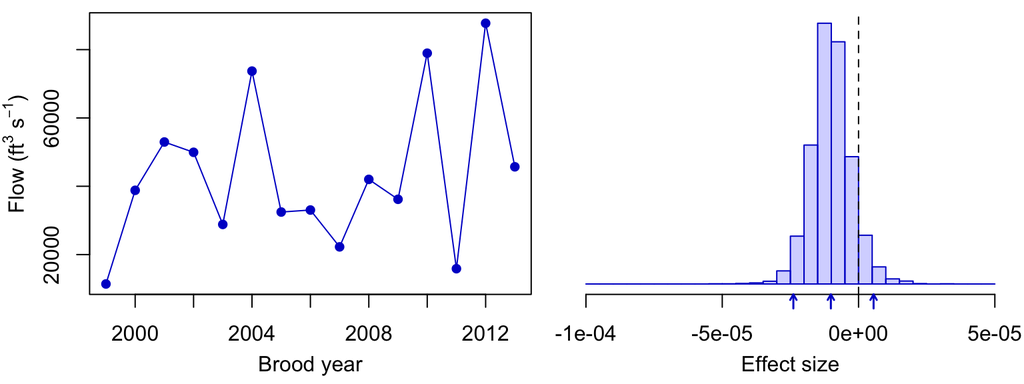

```r
clr <- rgb(0, 0, 255, alpha = 50, maxColorValue = 255)
par(mfrow=c(1,2), mai=c(0.7,0.2,0.1,0.1), omi=c(0,0.5,0,0))
t_idx <- seq(yr_frst,length.out=n_yrs-age_min+n_fore)
## plot covar ts
plot(t_idx, cov_flow[,best_idx+1],
     xlab="", ylab="", main="",
         cex.axis=1, pch=16, col="blue3", type="o")
mtext(side=1,"Brood year", line=2.2)
mtext(side=2, expression(paste("Flow (",ft^3," ",s^{-1},")")), line=2.2)
## plot covar effect
c_est <- mod_fit$BUGSoutput$sims.list$c1 / sd(cov_flow[,best_idx+1])
ylN <- floor(min(c_est)*20000)/20000
ylM <- ceiling(max(c_est)*20000)/20000
brks <- seq(ylN,ylM,length.out=31)
hist(c_est,
     freq=FALSE,breaks=brks,col=clr,border="blue3",
     xlab="", yaxt="n", main="", ylab="", cex.axis=1)
c_CI <- quantile(c_est,c(0.025,0.5,0.975))
aHt <- (par()$usr[4]-par()$usr[3])/20
arrows(c_CI,par()$usr[3]-0.005,c_CI,par()$usr[3]-aHt,
       code=1,length=0.05,xpd=NA,col="blue3",lwd=1.5)
abline(v=0, lty="dashed")
mtext(side=1,"Effect size", line=2.2)
```

The median covariate effect indicates that a 1000-unit increase in flow (ft<sup>3</sup> s<sup>-1</sup>) translates into a -1% change in recruits per spawner.

## 9.3 Total population size

Here is our estimate of the total run size (i.e., catch + escapement) over time, which includes a forecast for 2016. The black points are the data, the blue line is the median posterior estimate, and the shaded region is the 95% credible interval. Note that the y-axis is on a log scale.

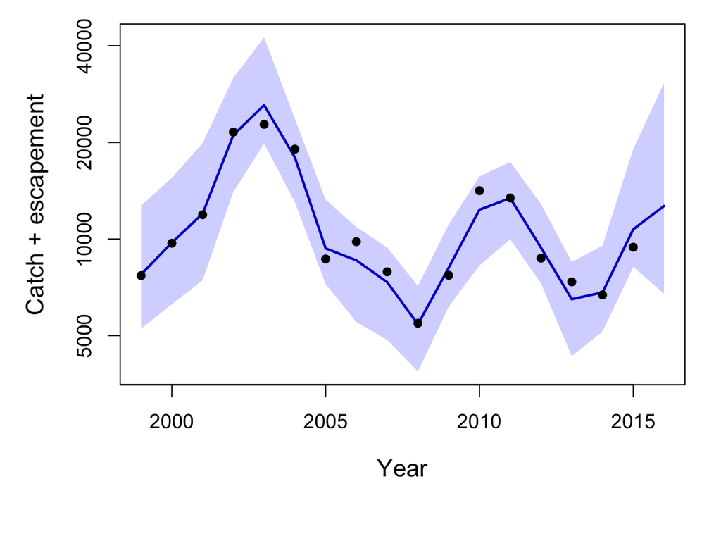

```r
pDat <- apply(mod_fit$BUGSoutput$sims.list$Sp,2,quantile,probs=CI_vec)
pDat <- pDat + matrix(dat_harv,length(CI_vec),n_yrs+n_fore,byrow=TRUE)
t_idx_f <- seq(yr_frst,length.out=n_yrs+n_fore)
ypMin <- min(pDat)
ypMax <- max(pDat)
par(mai=c(0.8,0.8,0.1,0.1), omi=c(0.5,0.2,0.1,0.2))
plot(t_idx_f,pDat[3,], ylim=c(ypMin,ypMax), type="n", log="y", xaxt="n", yaxt="n",
     xlab="Year", ylab="Catch + escapement", main="", cex.lab=1.2)
polygon(c(t_idx_f,rev(t_idx_f)),c(pDat[3,],rev(pDat[1,])), col=clr, border=NA)
lines(t_idx_f, pDat[2,], col="blue3", lwd=2)
points(t_idx_f, exp(ln_dat_esc)+dat_harv, pch=16, cex=1)
axis(1,at=seq(1980,2015,5))
axis(2,at=c(5000,10000,20000,40000,80000))
```

Here are several percentiles for the 2016 forecast for the total run size (i.e., catch + escapement).

```r
data.frame(forecast=round(quantile(mod_fit$BUGSoutput$sims.list$Sp[,n_yrs+n_fore],
                                   probs=c(0.025,0.25,0.5,0.75,0.975))))
```

```
##       forecast
## 2.5%      6749
## 25%      10064
## 50%      12673
## 75%      16495
## 97.5%    30594
```

# 10 Additional results

The following results are presented here as additional examples of model estimates.

## 10.1 Spawners over time

Here is the estimate of the number of spawners over time. The black points are the data, the blue line is the median posterior estimate, and the shaded region is the 95% credible interval. Note that there are no estimates of spawners in 1996 & 1997.

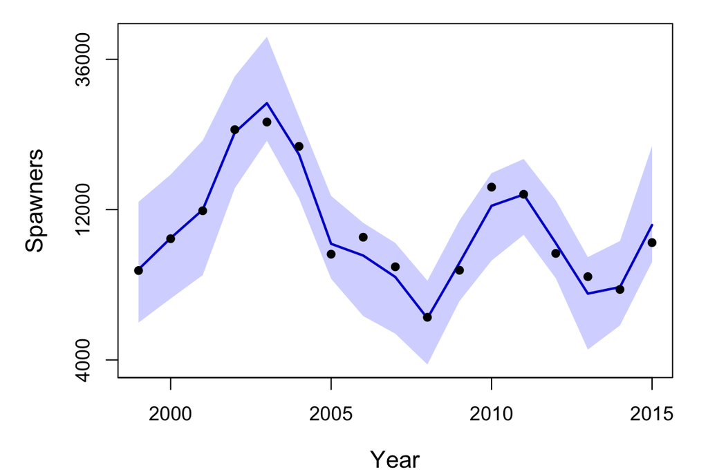

```r
pDat <- apply(mod_fit$BUGSoutput$sims.list$Sp,2,quantile,CI_vec)
ypMin <- min(pDat[,1:n_yrs])
ypMax <- max(pDat[,1:n_yrs])
t_idx_T <- seq(yr_frst,length.out=n_yrs)
par(mai=c(0.8,0.8,0.1,0.1), omi=c(0,0.2,0.1,0.2))
plot(t_idx_T,pDat[3,1:n_yrs], ylim=c(ypMin,ypMax), type="n", log="y", xaxt="n", yaxt="n",
     xlab="Year", ylab="Spawners", main="", cex.lab=1.2)
polygon(c(t_idx_T,rev(t_idx_T)),c(pDat[3,1:n_yrs],rev(pDat[1,1:n_yrs])), col=clr, border=NA)
lines(t_idx_T, pDat[2,1:n_yrs], col="blue3", lwd=2)
points(seq(yr_frst,length.out=n_yrs+n_fore), exp(ln_dat_esc), pch=16, cex=1)
axis(1,at=seq(1980,2015,5))
axis(2,at=c(4000,12000,36000))
```

## 10.2 Recruits over time

Here are the estimated total number of recruits by brood year (note that the y-axis is on a log scale). Again the uncertainty increases in recent years because fewer complete age classes have been observed.

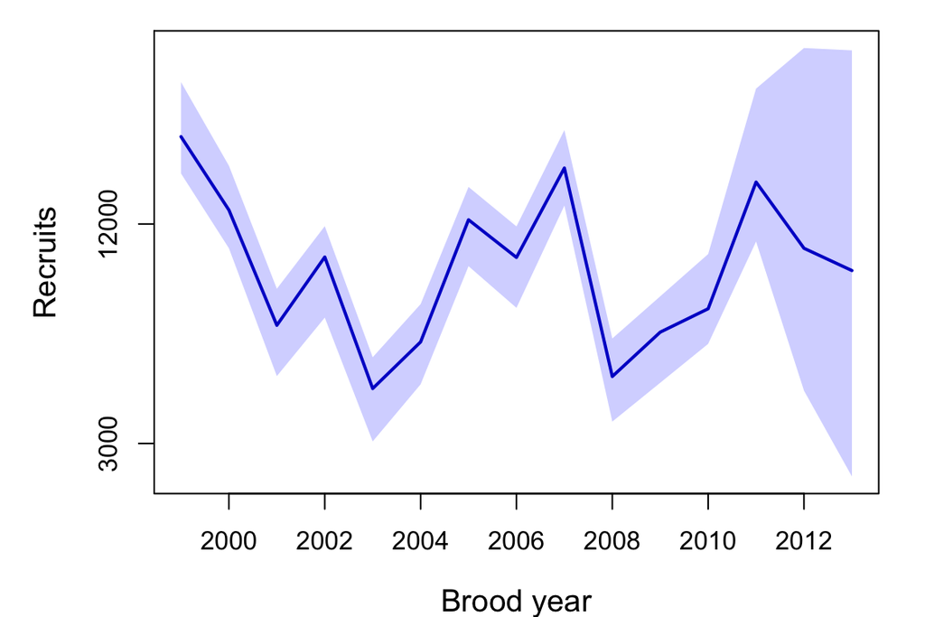

```r
CI_vec <- c(0.025,0.5,0.975)
pDat <- apply(mod_fit$BUGSoutput$sims.list$Rec,c(1,2),sum)
pDat <- apply(apply(pDat,2,sort),2,function(x) { x[mcmc_samp*CI_vec] })
ypMin <- min(pDat)
ypMax <- max(pDat)
t_idx_a <- seq(yr_frst,length.out=n_yrs-age_min+n_fore)
par(mai=c(0.8,0.8,0.1,0.1), omi=c(0,0.2,0.1,0.2))
plot(t_idx_a,pDat[3,], ylim=c(ypMin,ypMax), type="n", log="y", yaxt="n",
     xlab="Brood year", ylab="Recruits", main="", cex.lab=1.2)
axis(2,at=c(3000,12000,48000))
polygon(c(t_idx_a,rev(t_idx_a)),c(pDat[3,],rev(pDat[1,])), col=clr, border=NA)
lines(t_idx_a, pDat[2,], col="blue3", lwd=2)
```

## 10.3 Recruits per spawner

Here is the time series of estimated recruits-per-spawner. Values above (below) the dashed line at zero indicate positive (negative) population growth.

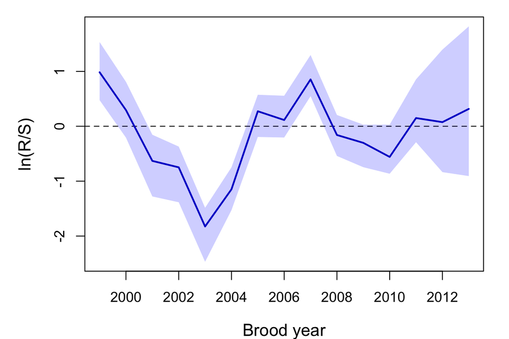

```r
pDat <- apply(mod_fit$BUGSoutput$sims.list$ln_RS,2,sort)
pDat <- apply(pDat,2,function(x) { x[mcmc_samp*CI_vec] })
pDat[2,] <- apply(mod_fit$BUGSoutput$sims.list$ln_RS,2,median)
ypMin <- min(pDat)
ypMax <- max(pDat)
par(mai=c(0.8,0.8,0.1,0.1), omi=c(0,0.2,0.1,0.2))
plot(t_idx_a,pDat[3,], ylim=c(ypMin,ypMax), type="n", #log="y",
     xlab="Brood year", ylab="ln(R/S)", main="", cex.lab=1.2)
abline(h=0, lty="dashed")
polygon(c(t_idx_a,rev(t_idx_a)),c(pDat[3,],rev(pDat[1,])), col=clr, border=NA)
lines(t_idx_a, pDat[2,], col="blue3", lwd=2)
```

## 10.4 Age composition

Here are time series of the estimated proportions of each age class by brood year (cohort).

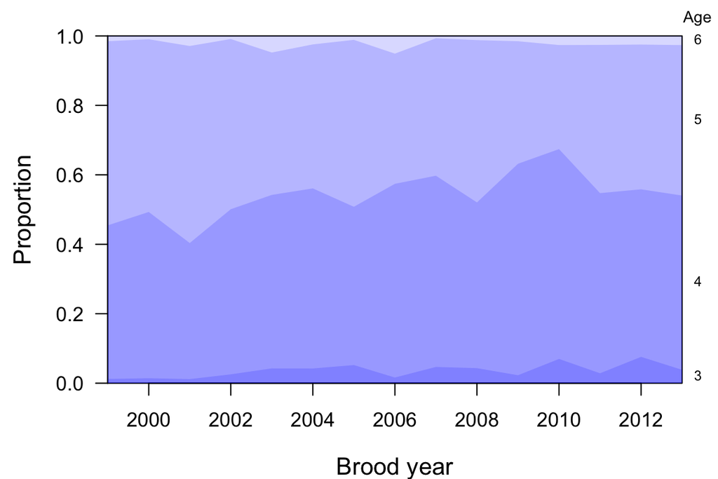

```r
par(mai=c(0.8,0.8,0.1,0.1), omi=c(0,0.1,0.2,0.2))
clr <- rgb(0, 0, 255, alpha = 40, maxColorValue = 255)
age_est <- t(apply(apply(mod_fit$BUGSoutput$sims.list$p_vec,c(3,2),mean),2,cumsum))
nRec <- n_yrs-age_min
plot(t_idx_a, rep(1,nRec+n_fore), ylab="Proportion", xlab="Brood year", ylim=c(0,1), las=1,
     xaxs="i", yaxs="i", type="n", lty="solid", col="blue3", cex.lab=1.2)
for(i in c(1,2,3,4)) {
    polygon(c(t_idx_a,rev(t_idx_a)),c(age_est[,i],rep(0,nRec+n_fore)), col=clr, border=NA)
    }
lbl <- apply(cbind(c(0,age_est[nRec+n_fore,-A]),age_est[nRec+n_fore,]),1,mean)
text(par()$usr[2],par()$usr[4]*1.05,"Age", xpd=NA, pos=4, offset=0.05, col="black", cex=0.8)
text(par()$usr[2],lbl[1:4],seq(3,6), xpd=NA, pos=4, col="black", cex=0.7)
text(par()$usr[2],lbl[5],"7&8", xpd=NA, pos=4, offset=0.15, col="black", cex=0.7)
```

## 10.5 Recruits by age class

Here are the estimated number of recruits by brood year and age. Note that the uncertainty increases in recent years as fewer complete age classes have been observed.

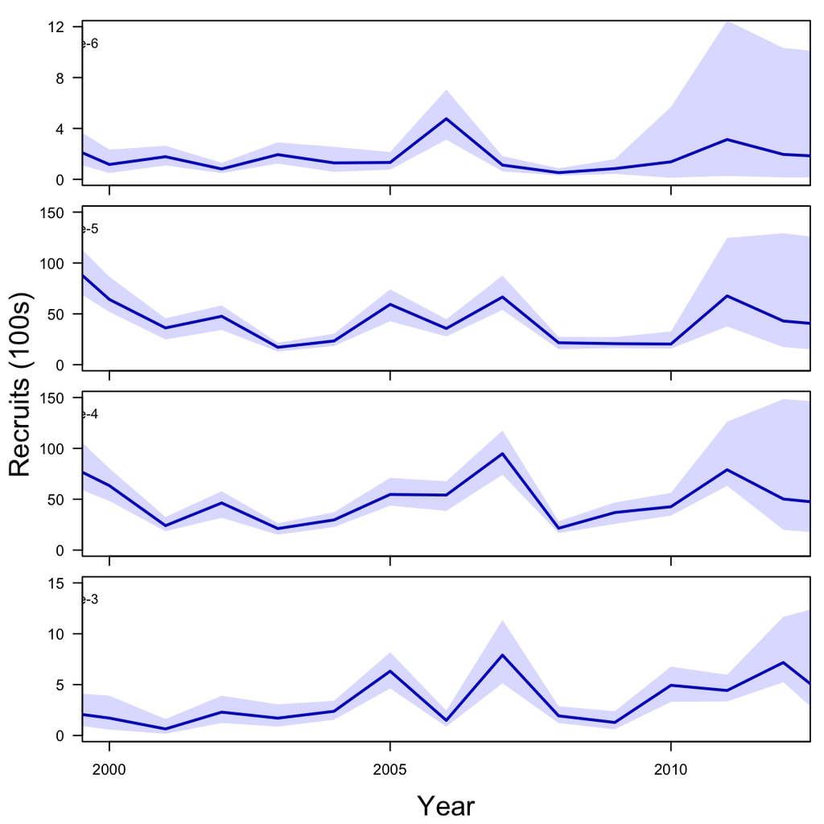

```r
CI_vec <- c(0.05,0.5,0.95)
par(mfrow=c(A,1), mai=c(0.1,0.1,0.05,0.1), omi=c(0.5,0.5,0.1,0))
t_idx_R <- seq(yr_frst,length.out=nRec+n_fore)
pltTT <- seq(min(round(t_idx_R/5,0)*5),max(round(t_idx_R/5,0)*5),5)
for(i in rev(1:A)) {
    pDat <- apply(mod_fit$BUGSoutput$sims.list$Rec[,,i],2,sort)
    pDat <- apply(pDat,2,function(x) { x[mcmc_samp*CI_vec] })/100
    dd <- ifelse(max(pDat)<20,1,10)
    ypMax <- Re2prec(max(pDat),prec=dd)
    while(ypMax %% 3 != 0) { ypMax <- ypMax + dd }
    plot(t_idx_R,pDat[3,], xlim=c(yr_frst+1,yr_last-n_fore-2), ylim=c(0.001,ypMax),
         type="n", xaxt="n", yaxt="n", xlab="", ylab="", main="", las=1)
    polygon(c(t_idx_R,rev(t_idx_R)),c(pDat[3,],rev(pDat[1,])), col=clr, border=NA)
    lines(t_idx_R, pDat[2,], col="blue3", lwd=2)
    aHt <- (par()$usr[4]-par()$usr[3])/7
    ttl <- paste("Age-",i+age_min-1,sep="")
    text(t_idx_R[1]-0, par()$usr[4]-aHt, ttl, pos=4, cex=0.9)
    axis(2,seq(0,ypMax,length.out=4),las=1,cex=0.9)
    if(i!=1) {axis(1,at=pltTT,labels=FALSE)} else {axis(1,at=pltTT)}
}
mtext("Recruits (100s)", 2, line=2, outer=TRUE, cex=1.2)
mtext("Year", 1, line=2.5, outer=TRUE, cex=1.2)
```

## 10.6 Time-varying productivity

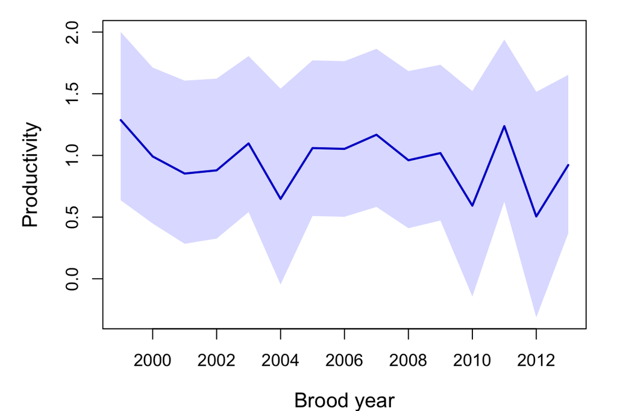

```r
pDat <- apply(mod_fit$BUGSoutput$sims.list$ln_Rkr_a,2,quantile,CI_vec)
ypMin <- min(pDat)
ypMax <- max(pDat)
par(mai=c(0.8,0.8,0.1,0.1), omi=c(0,0.2,0.1,0.2))
plot(t_idx_a,pDat[3,], ylim=c(ypMin,ypMax), type="n", #log="y",
     xlab="Brood year", ylab="Productivity", main="", cex.lab=1.2)
polygon(c(t_idx_a,rev(t_idx_a)),c(pDat[3,],rev(pDat[1,])), col=clr, border=NA)
lines(t_idx_a, pDat[2,], col="blue3", lwd=2)
```

## 10.7 Innovations

Here is the time series of the so-called “innovations”, which are the residuals from the process model. They give some indication of population productivity after accounting for the effects of density dependence.

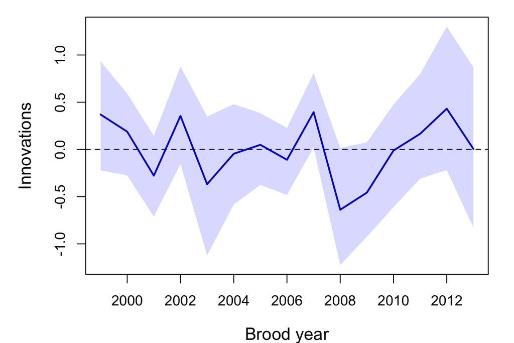

```r
pDat <- apply(mod_fit$BUGSoutput$sims.list$res_ln_Rec,2,quantile,CI_vec)
ypMin <- min(pDat)
ypMax <- max(pDat)
par(mai=c(0.8,0.8,0.1,0.1), omi=c(0,0.2,0.1,0.2))
plot(t_idx_a,pDat[3,], ylim=c(ypMin,ypMax), type="n", #log="y",
     xlab="Brood year", ylab="Innovations", main="", cex.lab=1.2)
abline(h=0, lty="dashed")
polygon(c(t_idx_a,rev(t_idx_a)),c(pDat[3,],rev(pDat[1,])), col=clr, border=NA)
lines(t_idx_a, pDat[2,], col="blue3", lwd=2)
```

## 10.8 Management reference points

Here are a number of management reference points.

```r
# abbreviations for ref points
ref_names <- c("MSY","Smsy","Umsy","Umax")
# proportions of MSY to consider
yld_prop <- c(0.75,0.85,0.95)
aa <- matrix(mod_fit$BUGSoutput$sims.array[,,"E_Rkr_a"],ncol=1)
alpha <- matrix(mod_fit$BUGSoutput$sims.array[,,"alpha"],ncol=1)
mcmc <- length(aa)
# empty matrix for ref pts
ref.pts <- matrix(NA,mcmc,length(ref_names))
colnames(ref.pts) <- ref_names
# spawner series for optimal yield profile
SS <- seq(100,3e4,100)
# empty matrix for optimal yield profiles
OYP <- matrix(0,length(SS),length(yld_prop))
for(i in 1:mcmc) {
    # spawners at MSY
    ref.pts[i,"Smsy"] <- (1 - lambert_W0(exp(1-aa[i]))) / bb[i]
    # MSY
    ref.pts[i,"MSY"] <- ref.pts[i,"Smsy"]*((exp(aa[i]-bb[i]*ref.pts[i,"Smsy"])) - 1)
    # harvest rate at MSY
    ref.pts[i,"Umsy"] <- (1 - lambert_W0(exp(1-aa[i])))
    # max harvest rate
    ref.pts[i,"Umax"] <- 1 - 1/alpha[i]
    # yield over varying S
    yield <- SS*(exp(aa[i]-bb[i]*SS) - 1)
    for(j in 1:length(yld_prop)) {
        OYP[,j] <- OYP[,j] + 1*(yield > yld_prop[j]*ref.pts[i,"MSY"])
    }
}
OYP <- OYP/mcmc

## Prob of overfishing
hh <- seq(100)
Pr_over <- cbind(hh,hh,hh)
colnames(Pr_over) <- c("Umsy75","Umsy","Umax")
for(i in hh) {
  Pr_over[i,"Umsy75"] <- sum(ref.pts[,"Umsy"]*0.75 < i/100)/mcmc_samp
  Pr_over[i,"Umsy"] <- sum(ref.pts[,"Umsy"] < i/100)/mcmc_samp
  Pr_over[i,"Umax"] <- sum(ref.pts[,"Umax"] < i/100)/mcmc_samp
}

## posterior exploitation rate & spawner abundance
aer <- Sp_ts <- mod_fit$BUGSoutput$sims.list$Sp[,1:n_yrs]
for(i in 1:n_yrs) {
    aer[,i] <- dat_harv[i] / (dat_harv[i] + Sp_ts[,i])
}
```

These are plots of (a) the probability that a given number of spawners produce average yields exceeding X% of MSY (i.e, optimal yield profiles); and (b) the cumulative probabilty of overfishing the population, based on harvest rates equal to those at 75% of MSY $(U_{\text{M75}})$, MSY $(U_{\text{MSY}})$, and the maximum $(U_{\text{Max}})$. The probability of exceeding $U_{\text{Max}}$ indicates the risk that offspring will not replace their parents, which, if sustained, will lead to eventual extinction. The histograms above (a) and (b) are distributions of the posterior estimates for the number of spawners and harvest rates, respectively.

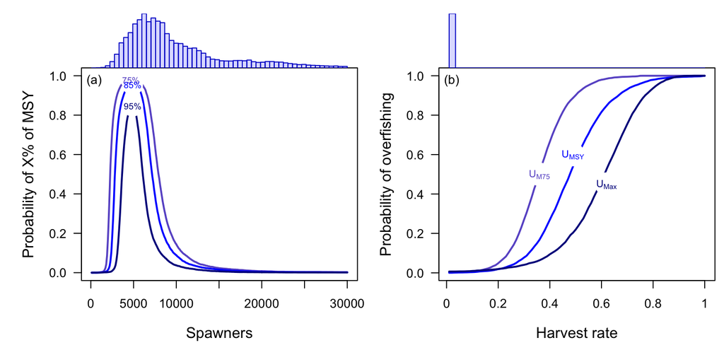

```r
layout(matrix(c(2,1,4,3),2,2),heights=c(1,5))

## OYP
par(mai=c(0.9,0.9,0,0), omi=c(0,0,0.1,0.1))
x_lp <- y_lp <- yld_prop
for(i in 1:length(x_lp)) {
    x_lp[i] <- SS[max(which(OYP[,i] == max(OYP[,i])))]
    y_lp[i] <- max(OYP[,i])
}
matplot(SS, OYP, type="l", lty="solid", las=1, col=c("slateblue","blue","darkblue"), lwd=2,
        xlab="Spawners", ylab="Probability of X% of MSY", cex.lab=1.2,
        main="", ylim=c(0,1))
points(x=x_lp, y=y_lp, pch=21, cex=3.5, col="white", bg="white")
text(x=x_lp, y=y_lp, paste0(yld_prop*100,"%"),
     col=c("slateblue","blue","darkblue"), cex=0.7)
text(x=par()$usr[1]+par()$pin[2]/par()$pin[1]*offSet*diff(par()$usr[1:2]),
     y=par()$usr[4]-offSet*diff(par()$usr[3:4]),"(a)")
## posterior spawner abundance over all years
par(mai=c(0,0.9,0.05,0))
hist(Sp_ts[Sp_ts<3e4], col=clr, border="blue3", breaks=40,
      main="", yaxs="i", xaxt="n",yaxt="n",ylab="")

## prob of overfishing
par(mai=c(0.9,0.9,0,0))
matplot(Pr_over, type="l", las=1, lwd=2, lty="solid", col=c("slateblue","blue","darkblue"),
        ylab="Probability of overfishing", cex.lab=1.2,
        xlab="Harvest rate", xaxt="n")
axis(1,seq(0,100,20),seq(0,100,20)/100)
x_lp <- c(0,0,0)
for(i in 1:length(x_lp)) {
    x_lp[i] <- max(which(abs(Pr_over[,i] - 0.5) <= 0.05))
}
x_lp[3] <- max(which(abs(Pr_over[,i] - 0.5) <= 0.05))
y_lp <- c(0.5,0.6,0.45)
points(x=x_lp, y=y_lp, pch=21, cex=4, col="white", bg="white")
text(x=x_lp, y=y_lp, expression(U[M75], U[MSY], U[Max]),
     col=c("slateblue","blue","darkblue"), cex=0.8)
text(x=par()$usr[1]+par()$pin[2]/par()$pin[1]*offSet*diff(par()$usr[1:2]),
     y=par()$usr[4]-offSet*diff(par()$usr[3:4]),"(b)")
## posterior harvest rates over all years
par(mai=c(0,0.9,0.05,0))
hist(aer, col=clr, border="blue3", breaks=seq(0,40)/40,
      main="", yaxs="i", xaxt="n",yaxt="n",ylab="")
```